**Disclaimer**: Notebooks translated to Spanish are distributed as an optional aid to assist in your learning and comprehension. We make no guarantees that the translations are completely accurate nor that the translated code blocks will run properly.

# ¿Existen diferencias significativas entre los saldos de las diferentes cohortes de mis clientes?

## Objetivos (3 min)

Uno de los problemas clave en la ciencia de datos es determinar si un patrón que hemos notado es lo suficientemente significativo como para ameritar acciones adicionales. En este caso, va a aprender una herramienta fundamental para trabajar en este problema, llamada **pruebas de hipótesis**. Al final de este caso, usted sabrá cómo realizar una prueba de hipótesis, analizar sus resultados e identificar sus limitaciones.

## Introducción (5 min)

**Contexto de negocios.** Usted está liderando una unidad de análisis de negocios en un banco y se le ha pedido apoyar a la unidad de mercado para realizar un análisis de segmentación de los clientes. Se le da un conjunto de datos que contiene una muestra de los clientes, sus saldos en la cuenta del banco e información demográfica acerca de ellos. Poblaciones diferentes en todo el país tienen niveles de ingreso diferentes, y pueden tener perfiles de gasto diferentes. Su equipo de mercado quiere saber si hay diferencias significativas en los saldos bancarios de los diferentes subsegmentos de su base de clientes, de manera que puedan diseñar productos focalizados a diferentes grupos.

**Problema de negocios.** El departamento de mercadeo quiere que usted determine: **¿Hay diferencias estadísticamente significativas en los saldos bancarios de sus segmentos de clientes (por edad, ocupación, educación, estado civil, etc.)?**

**Contexto analítico.** El conjunto de datos que usaremos en este caso fue tomado de [Kaggle](https://www.kaggle.com/skverma875/bank-marketing-dataset). En este caso, daremos el primer paso hacia la transición de **Análisis exploratorio de datos** al análisis **confirmatorio**. Nosotros (1) aprenderemos un marco formal para hacer pruebas de hipótesis, (2) aprenderemos acerca de los $p-valores$, (3) generaremos una hipótesis a partir del análisis exploratorio de datos, y (4) finalmente analizaremos los resultados de una prueba de hipótesis.

```python
import pandas as pd
import numpy as np
import matplotlib.pyplot as plt
import seaborn as sns
import statsmodels.api as sm
from statsmodels.formula.api import ols
import statsmodels
from scipy import stats
from pingouin import pairwise_ttests # Este paquete sirve para hacer las pruebas por parejas de variables
```

## Exploración de los datos (15 min)

Los datos incluyen los saldos de las cuentas de 45.211 clientes, junto con varias otras características:

```python
banco = pd.read_csv("bank-full.csv")
banco.shape
```

```
(45211, 17)
```

```python
banco.head()
```

|  | age | job | marital | education | default | balance | housing | loan | contact | day | month | duration | campaign | pdays | previous | poutcome | y |
| --- | --- | --- | --- | --- | --- | --- | --- | --- | --- | --- | --- | --- | --- | --- | --- | --- | --- |
| 0 | 58 | management | married | tertiary | no | 2143 | yes | no | unknown | 5 | may | 261 | 1 | -1 | 0 | unknown | no |
| 1 | 44 | technician | single | secondary | no | 29 | yes | no | unknown | 5 | may | 151 | 1 | -1 | 0 | unknown | no |
| 2 | 33 | entrepreneur | married | secondary | no | 2 | yes | yes | unknown | 5 | may | 76 | 1 | -1 | 0 | unknown | no |
| 3 | 47 | blue-collar | married | unknown | no | 1506 | yes | no | unknown | 5 | may | 92 | 1 | -1 | 0 | unknown | no |
| 4 | 33 | unknown | single | unknown | no | 1 | no | no | unknown | 5 | may | 198 | 1 | -1 | 0 | unknown | no |

Las características relevantes que usaremos en este caso son:

1. **balance:** Saldo en la cuenta del banco, la variable de interés clave
2. **job:** El título del cargo (administración”, “técnico”, etc)
3. **marital:** Estado civil ("soltero", "casado" or "divorciado")
4. **education:** Diferentes niveles de educación ("primaria","secundaria","terciaria","desconocido")
5. **default:** El cliente falló en pagar su deuda ("sí" o "no)
6. **loan:** El cliente obtuvo un préstamo ("sí" o "no)

```python
banco.describe()
```

|  | age | balance | day | duration | campaign | pdays | previous |
| --- | --- | --- | --- | --- | --- | --- | --- |
| count | 45211.000000 | 45211.000000 | 45211.000000 | 45211.000000 | 45211.000000 | 45211.000000 | 45211.000000 |
| mean | 40.936210 | 1362.272058 | 15.806419 | 258.163080 | 2.763841 | 40.197828 | 0.580323 |
| std | 10.618762 | 3044.765829 | 8.322476 | 257.527812 | 3.098021 | 100.128746 | 2.303441 |
| min | 18.000000 | -8019.000000 | 1.000000 | 0.000000 | 1.000000 | -1.000000 | 0.000000 |
| 25% | 33.000000 | 72.000000 | 8.000000 | 103.000000 | 1.000000 | -1.000000 | 0.000000 |
| 50% | 39.000000 | 448.000000 | 16.000000 | 180.000000 | 2.000000 | -1.000000 | 0.000000 |
| 75% | 48.000000 | 1428.000000 | 21.000000 | 319.000000 | 3.000000 | -1.000000 | 0.000000 |
| max | 95.000000 | 102127.000000 | 31.000000 | 4918.000000 | 63.000000 | 871.000000 | 275.000000 |

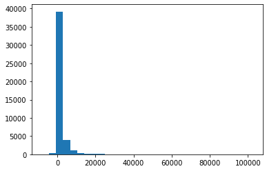

```python
plt.hist(banco['balance'],bins = 30);
```

### Ejercicio 1: (3 min)

En las tablas y el histograma de arriba, vemos un gran rango en los balances bancarios de sus clientes. ¿Por qué cree que se da esto?

**Respuesta.**

Entendamos mejor nuestros datos graficando las variables. Consideremos las variables `job`, `marital`, `education`, `default`, `housing`, `loan`. Para cada una de estas variables, graficamos el número de clientes en cada categoría así:

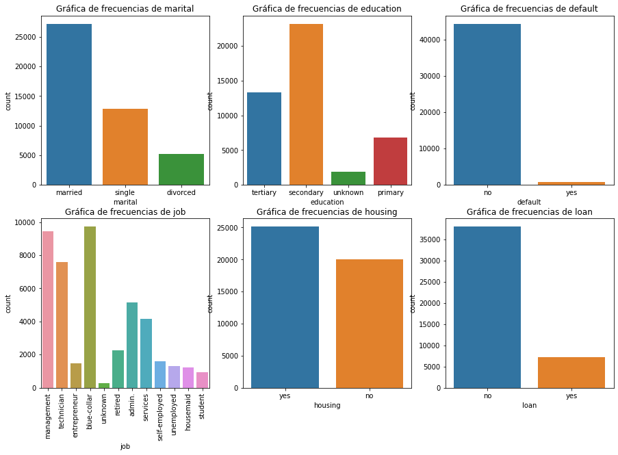

```python
plt.figure(figsize=(15,10))
variables_a_revisar = ['marital','education','default','job','housing','loan']
for i, var in enumerate(variables_a_revisar):
    plt.subplot(2,3,i+1)
    if i ==3:
        plt.xticks(rotation = 90)
    sns.countplot(banco[var])
    plt.title("Gráfica de frecuencias de " + var)
```

### Ejercicio 2: (3 min)

¿Qué puede concluir a partir de los gráficos?

### Ejercicio 3: (3 min)

El año pasado el saldo promedio de toda la población de los clientes del banco fue de 1341,12 dólares. ¿Cuánto más alto es el saldo promedio de la muestra este año? ¿Esta diferencia es significativa?

**Respuesta.**

## Marco analítico para las pruebas de hipótesis (20 min)

El procedimiento que usamos para ayudarnos a decidir si una diferencia entre el promedio $\mu$ de una población y un valor de referencia $\mu_0$ es **significativa estadísticamente** se llama **prueba de hipótesis**. En nuestro contexto, $\mu$ es el promedio del saldo bancario de los clientes este año y $\mu_0$ es el promedio del saldo bancario del año pasado.

El primer paso es definir la hipótesis nula (a menudo indicada como $H_0$). Para nosotros, la hipótesis nula **siempre** corresponderá a la hipótesis de no cambio; es decir, que el *statu quo* sigue siendo válido. Formalmente, esto se escribe como: $ H_0: \mu = \mu_0 $.

En nuestro caso, $H_0$ sería equivalente a formular la hipótesis de que el saldo medio de toda la población de clientes $\mu$ es el mismo que el saldo medio del año pasado $\mu_0 = \$1341.12$. Deseamos probar si $H_0$ está equivocado; es decir, si $\mu$ es diferente de $\mu_0 = \$1341.12$.

Antes de profundizar en el caso, piense en la siguiente pregunta:

### Pregunta: (5 min)

Suponga que usted es Ronald Fisher en los años 20 y que descubre por primera vez la prueba de hipótesis. ¿Cómo haría para probar la veracidad de la hipótesis nula $H_0$?

**Respuesta:**

### Hipótesis alternativa (3 min)

En contraste con la hipótesis nula, definimos una hipótesis alternativa (a menudo indicada con $H_1$ o $H_a$) para desafiar el *statu quo*. Podemos tener tres formas diferentes de definir una hipótesis alternativa:

1. $H_a: \mu \neq \mu_0$ (prueba de dos colas)
2. $H_a: \mu > \mu_0$ (prueba de una sola cola)
3. $H_a: \mu < \mu_0$ (prueba de una sola cola)

La prueba estadística nos ayudará a decidir si hay suficiente evidencia para rechazar la hipótesis nula a favor de una alternativa.

### Realizando una prueba de hipótesis (3 min)

Volviendo a nuestro caso, supongamos que deseamos realizar una prueba estadística para evaluar la hipótesis de los gerentes:

$$ H_0: \mu= 1341.12$$ $$ H_a: \mu \neq 1341.12$$

Hay dos posibles resultados para esta prueba: (1) Concluir que $H_0$ es falso, y decir que **rechazamos $H_0$**. En este caso concluiremos que hay evidencia estadística para la alternativa $H_a$ y que el saldo bancario de los clientes este año es efectivamente diferente de 1341.12 dólares. O (2) **no rechazamos $H_0$**. En este caso, concluimos que no hay suficiente evidencia estadística para decir con seguridad que $H_0$ es falso. **Notamos que en el segundo caso no podemos decir que la hipótesis original es verdadera.** (De hecho, no hay ninguna prueba que diga que una hipótesis es verdadera. ¿Por qué puede ser esto?)

```python
stats.ttest_1samp(banco['balance'], popmean=1341.122)
```

```
Ttest_1sampResult(statistic=1.4769973489267905, pvalue=0.13968331332845219)
```

### Pregunta: (2 min)

¿Qué concluye de los resultados? ¿Rechazamos $H_0$ o la mantenemos?

**Respuesta.**

**Nota:** Si la alternativa es de una sola cola, digamos $H_a: \mu > \mu_0$ o $H_a: \mu < \mu_0$, entonces simplemente ejecute la prueba de dos caras y luego divida el valor de $p$ por la mitad.

```python
T,p = stats.ttest_1samp(banco['balance'], popmean=1341.122)
p_valor = p/2
p_valor
```

```
0.06984165666422609
```

### Ejercicio 4: (3 min)

Hemos retenido $H_0$. ¿Estamos 100% seguros de que esta decisión es correcta? ¿Por qué o por qué no?

**Respuesta:**

## Errores causados por una conclusión errónea sacada una prueba de hipótesis (10 min)

Hay dos formas en que una prueba puede llevarnos a una decisión incorrecta:

1. Cuando $H_0$ es verdadero y lo rechazamos. Esta situación se llama **Error de tipo 1**. Corresponde a obtener un **positivo falso**.
2. Cuando $H_0$ es falso y no lo rechazamos. Esto se llama **Error de tipo 2**. Corresponde a tener un **falso negativo**.

|  | **$H_0$ es verdadera** | **$H_0$ es falsa** |
| --- | --- | --- |
| **Rechazar $H_0$** | Error tipo I | Decisión correcta (verdadero positivo) |
| **No rechazar $H_0$** | Decisión correcta (verdadero negativo) | Error tipo II |

En general, no podemos controlar tanto el error de Tipo I como el de Tipo II. Así que el tipo de error que controlaremos dependerá de la situación.

### Ejercicio 5: (5 min)

Discuta los siguientes dos escenarios con sus compañeros de equipo:

1. Un paciente se está haciendo una prueba de diagnóstico para saber si está infectado con el virus del VIH. ¿Cuál es la hipótesis nula aquí? ¿Qué es más grave aquí: cometer un error de tipo I (falso positivo) o de tipo II (falso negativo)? ¿Por qué?
2. Está recibiendo muchos correos electrónicos de spam, así que decidió escribir un algoritmo de filtro de spam para detectar si un correo electrónico es spam o no. ¿Cuál es la hipótesis nula aquí? ¿Qué es más grave aquí: cometer un error de tipo I (falso positivo) o un error de tipo II (falso negativo)? ¿Por qué?

**Respuesta.**

## Control del error de tipo I: nivel de significancia (15 min)

Es una práctica estándar minimizar la probabilidad de cometer un error de Tipo I. La probabilidad, usualmente denotada por $\alpha$, es el nivel de significancia que introdujimos anteriormente. Típicamente elegimos nuestro nivel de significancia $\alpha$ para que sea de $5\%$. Por lo tanto, si rechazamos $H_0$ con $\alpha = 0.05$, entonces sólo hay una probabilidad de $5\%$ de que la conclusión que obtengamos sea un falso positivo. Bajar el valor de $\alpha$ (digamos a $1\%$) disminuirá la probabilidad de llegar a una conclusión positiva falsa.

Por supuesto, como discutimos antes, como controlamos el valor $\alpha$, no podemos controlar el error de tipo II.

### Encontrando cohortes dentro de su base de clientes (5 min)

El objetivo de su equipo es determinar si existen diferencias entre los distintos grupos de clientes en cuanto a los saldos bancarios. Empezamos mirando los saldos de dos cohortes: los que pidieron un préstamo y los que no:

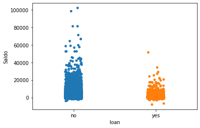

```python
ax = sns.stripplot(x="loan", y="balance", data=banco)
plt.ylabel('Saldo')
plt.show()
```

Como la distribución de los datos tiene colas densas, es difícil determinar a partir de la gráfica de franjas si hay una diferencia entre las medias de los dos subgrupos. Continuamos nuestro análisis de datos mirando las estadísticas de resumen para cada uno de los dos grupos:

```python
banco[banco.loan=="yes"].balance.describe()
```

```
count     7244.000000
mean       774.309912
std       1908.283253
min      -8019.000000
25%          2.000000
50%        258.000000
75%        864.250000
max      51439.000000
Name: balance, dtype: float64
```

```python
banco[banco.loan=="no"].balance.describe()
```

```
count     37967.000000
mean       1474.453631
std        3204.088951
min       -4057.000000
25%          94.000000
50%         496.000000
75%        1558.000000
max      102127.000000
Name: balance, dtype: float64
```

### ¿Son significativamente diferentes las medias de los grupos con préstamo y sin préstamo? (5 min)

Nos gustaría comprobar estadísticamente si las medias de los dos grupos son diferentes entre sí; es decir, si la diferencia entre el saldo medio de los grupos con un préstamo ($\mu_1$) es diferente del saldo medio del grupo sin préstamo ($\mu_2$). El procedimiento para hacer pruebas que describimos antes puede utilizarse también para responder a esta pregunta:

$$ H_0: \mu_1=\mu_2$$ $$H_a: \mu_1 \neq \mu_2$$

Tenemos el siguiente resultado:

```python
con_prestamo=banco[banco.loan=="yes"].balance
sin_prestamo=banco[banco.loan=="no"].balance

estadistico, pvalor = stats.ttest_ind(con_prestamo,sin_prestamo, equal_var=False)
estadistico, pvalor
```

```
(-25.18086057755715, 2.7640564777544156e-137)
```

### Pregunta: (2 min)

¿Qué concluiría a partir de la prueba anterior?

**Respuesta:**

### Diferencias por nivel de educación (5 min)

Como parte de nuestra búsqueda para determinar qué factores son importantes en la segmentación de clientes, podemos identificar en este gran conjunto de datos si la educación juega un papel en el comportamiento de los clientes. La variable `education` tiene 4 categorías:

```python
banco["education"].unique()
```

```
array(['tertiary', 'secondary', 'unknown', 'primary'], dtype=object)
```

### Exercise 6: ( 3 min)

A continuación hemos escrito código para dibujar el saldo por nivel de educación a través de un gráfico de franjas (es decir, un gráfico de dispersión 1D agrupado). A partir de su exploración visual, ¿cree que hay una diferencia entre los grupos?

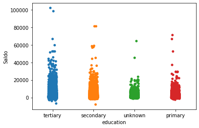

```python
ax = sns.stripplot(x="education", y="balance", data=banco)
plt.ylabel('Saldo')
plt.show()
```

**Responde.**

## ¿Difieren significativamente los saldos bancarios entre las cohortes según nivel de educación? (25 min)

Nuestra nueva hipótesis será:

$$ H_0: \mu_1=\mu_2=\mu_3=\mu_4$$ $$H_a : \mathrm{Al \,menos\, una\, de\, las\, medias\,} \mu_j \mathrm{\,es \,diferente\, de\, las \,otras}.$$

Para probar esta hipótesis necesitamos aumentar las capacidades de la prueba de $t$ (que puede probar sólo dos grupos al mismo tiempo). Esta prueba se llama **Análisis de Varianza (ANOVA)**.

```python
mod = ols('balance ~ education', data=banco).fit()
anova_tabla = sm.stats.anova_lm(mod, typ=2)
anova_tabla
```

|  | sum_sq | df | F | PR(>F) |
| --- | --- | --- | --- | --- |
| education | 3.220417e+09 | 3.0 | 116.682074 | 2.849538e-75 |
| Residual | 4.159034e+11 | 45207.0 | NaN | NaN |

Como podemos ver, mirando el $p$ - valor que acompaña al estadístico $F$ obtenemos un fuerte rechazo de la hipótesis nula, lo que nos lleva a concluir que los grupos de educación tienen algunas diferencias en sus medias. El test ANOVA no nos dice qué par de grupos tienen medias diferentes entre sí. Para investigar estas diferencias más a fondo, vamos a informar primero de las estadísticas descriptivas por grupo, y luego vamos a mostrar las medias de los grupos en un gráfico de barras:

```python
banco[banco.education=="primary"].balance.describe()
```

```
count     6851.000000
mean      1250.949934
std       2690.743991
min      -2604.000000
25%         61.000000
50%        403.000000
75%       1390.000000
max      71188.000000
Name: balance, dtype: float64
```

```python
banco[banco.education=="secondary"].balance.describe()
```

```
count    23202.000000
mean      1154.880786
std       2558.256739
min      -8019.000000
25%         55.000000
50%        392.000000
75%       1234.000000
max      81204.000000
Name: balance, dtype: float64
```

```python
banco[banco.education=="tertiary"].balance.describe()
```

```
count     13301.000000
mean       1758.416435
std        3839.088305
min       -6847.000000
25%         104.000000
50%         577.000000
75%        1804.000000
max      102127.000000
Name: balance, dtype: float64
```

```python
banco[banco.education=="unknown"].balance.describe()
```

```
count     1857.000000
mean      1526.754443
std       3152.228273
min      -1445.000000
25%        106.000000
50%        568.000000
75%       1699.000000
max      64343.000000
Name: balance, dtype: float64
```

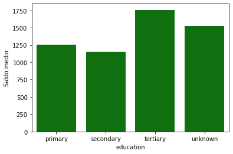

```python
saldo_medio_educacion=banco.groupby(by="education").balance.mean()
sns.barplot(x=saldo_medio_educacion.index, y=saldo_medio_educacion.values, color="green")
plt.ylabel("Saldo medio")
plt.show()
```

Cualitativamente parece haber una gran diferencia entre los niveles de educación terciaria y los inferiores, pero la diferencia entre los grupos de educación primaria y secundaria es más difícil de evaluar. Queremos comprobar si hay una diferencia significativa en cada comparación por pares. Para probar esta secuencia de hipótesis podemos usar una variante del test de $t$, llamado **test $t$ por pares**.

```python
gb = banco.groupby(['education'])
nombres_de_grupos = banco["education"].unique()
print("\t\t\testadistico\t\tpvalor")
for i in range(len(nombres_de_grupos)):
  for j in range(i+1, len(nombres_de_grupos)):
    grupo1 = gb[["balance"]].get_group(nombres_de_grupos[i])
    grupo2 = gb[["balance"]].get_group(nombres_de_grupos[j])
    estadistico, pvalor = stats.ttest_ind(grupo1, grupo2, equal_var = False)
    print(nombres_de_grupos[i] + " vs. " + nombres_de_grupos[j] + "\t" + str(estadistico[0]) + "\t" + str(pvalor[0]))
```

```
			estadistico		pvalor
tertiary vs. secondary	16.18717929985782	1.4525474790099814e-58
tertiary vs. unknown	2.8825321831203117	0.003976238237673688
tertiary vs. primary	10.906634331433306	1.3023845080432282e-27
secondary vs. unknown	-4.95482328681934	7.83111710943088e-07
secondary vs. primary	-2.6255174227477864	0.0086639693661419
unknown vs. primary	3.445496944400963	0.0005789323657180873
```

El resultado resumido anterior indica que hay una diferencia significativa entre cada comparación por pares.

### Ejercicio 7: (4 min)

Hay seis comparaciones en total que deben realizarse porque la variable educación tiene 4 niveles. Discuta con un compañero si, en su opinión, la realización de múltiples pruebas simultáneamente puede aumentar el riesgo de inferencias erróneas. Qué aumentará: ¿el error de tipo I o el del tipo II?

**Respuesta.**

### Múltiples comparaciones: la corrección de Bonferroni (15 min)

Hay muchas maneras de corregir este problema, conocido como el problema de las "comparaciones múltiples". Uno de los métodos más clásicos es la corrección de Bonferroni. Este método divide el nivel de significancia $\alpha$ por el número de comparaciones múltiples que se realizan (6 en este caso). Así que si nuestro $\alpha=0,05$ rechazaremos la hipótesis nula sólo si el valor $p$ es menor que 0,00833.

```python
resultados_por_pares = pairwise_ttests(dv='balance', between = ['education'], padjust='bonf', data=banco)
resultados_por_pares
```

|  | Contrast | A | B | Paired | Parametric | T | dof | Tail | p-unc | p-corr | p-adjust | BF10 | hedges |
| --- | --- | --- | --- | --- | --- | --- | --- | --- | --- | --- | --- | --- | --- |
| 0 | education | tertiary | secondary | False | True | 16.187179 | 20183.403282 | two-sided | 1.452547e-58 | 8.715285e-58 | bonf | 5.742e+54 | 0.195497 |
| 1 | education | tertiary | unknown | False | True | 2.882532 | 2688.204879 | two-sided | 3.976238e-03 | 2.385743e-02 | bonf | 1.76 | 0.061581 |
| 2 | education | tertiary | primary | False | True | 10.906634 | 18353.418018 | two-sided | 1.302385e-27 | 7.814307e-27 | bonf | 9.088e+23 | 0.145344 |
| 3 | education | secondary | unknown | False | True | -4.954823 | 2056.380989 | two-sided | 7.831117e-07 | 4.698670e-06 | bonf | 5633.685 | -0.142646 |
| 4 | education | secondary | primary | False | True | -2.625517 | 10768.241876 | two-sided | 8.663969e-03 | 5.198382e-02 | bonf | 0.486 | -0.037105 |
| 5 | education | unknown | primary | False | True | 3.445497 | 2633.681528 | two-sided | 5.789324e-04 | 3.473594e-03 | bonf | 10.941 | 0.098651 |

### Ejercicio 8: (10 min)

1. ¿Son las medias del grupo las mismas? Escriba una hipótesis para esto, indicando claramente lo que es $H_0$.
2. Haga una prueba de hipótesis por pares para comparar las diferentes medias del grupo, aplicando la corrección de Bonferroni.
3. ¿Le sorprende alguno de los resultados de las pruebas de hipótesis de los clientes con cargos de `management` (gerenciales) frente a otros grupos?

**Respuesta.**

## Puntos clave (5 min)

En este caso hemos dado un primer paso desde el análisis exploratorio de los datos hasta el análisis confirmatorio. Hemos:

1. Introducido el concepto de prueba de hipótesis. Esta herramienta le ayudará con los problemas que implican la detección de diferencias entre poblaciones. Problemas como este serán comunes en su trabajo como científico de datos.
2. Comprendido la importancia de reconocer cuándo los cambios en nuestros datos corresponden a mera fluctuación natural o no, y cómo las pruebas de hipótesis pueden ayudarnos en este problema.
3. Aprendido a interpretar el resultado de una prueba de hipótesis usando $p$ valores. Este concepto aparece en muchos modelos que se utilizan en la ciencia de los datos y también lo veremos en varios casos futuros.
4. Entendido los riesgos de realizar múltiples comparaciones con los mismos datos y vimos una forma de prevenir estos riesgos usando la corrección de Bonferroni. Recuerde, "Si torturamos los datos lo suficiente, los haremos confesar".